# Are College Teams Passing More on First Down?

Jetson Ku

2022-11-10

As we did a couple weeks ago, we will be using cfbfastR to answer a question that we have about a trend in playcalling. Are teams in college football passing more on first down? Let’s find out. First we’re going to pull all the plays since 2014 in the data.

```r
library(tidyverse)
library(cfbfastR)
library(dplyr)

tictoc::tic()
pbp <- data.frame()
seasons <- 2014:cfbfastR:::most_recent_cfb_season()
progressr::with_progress({

  pbp <- cfbfastR::load_cfb_pbp(seasons)
})
tictoc::toc()
```

```
## 39.66 sec elapsed
```

We’re going to use the “down” column to filter out plays that are from first down. Unfortunately this includes some kickoffs and kickoff returns. If we filter out all punts and kickoffs, that should give us all plays from scrimmage. We need to start with a broad filter so we can find the percentage of these plays that are passes later.

```r
first_downs <- pbp %>% filter(down == 1, play_type != 'Punt', !grepl("Kickoff", play_type))
```

And then I’m going to create a dataframe that has the percentage of these plays that were passes, but separated by year. We can do this by grouping the rows by year and then calculating the percentage for each year. This will give us an idea of how the percentage has changed in the last 8 seasons.

```r
by_year <- first_downs %>% group_by(year) %>% summarise(passes = sum(pass), count = n()) %>% mutate(percentage = passes/count)
```

We can see it visually by plotting it as a line chart.

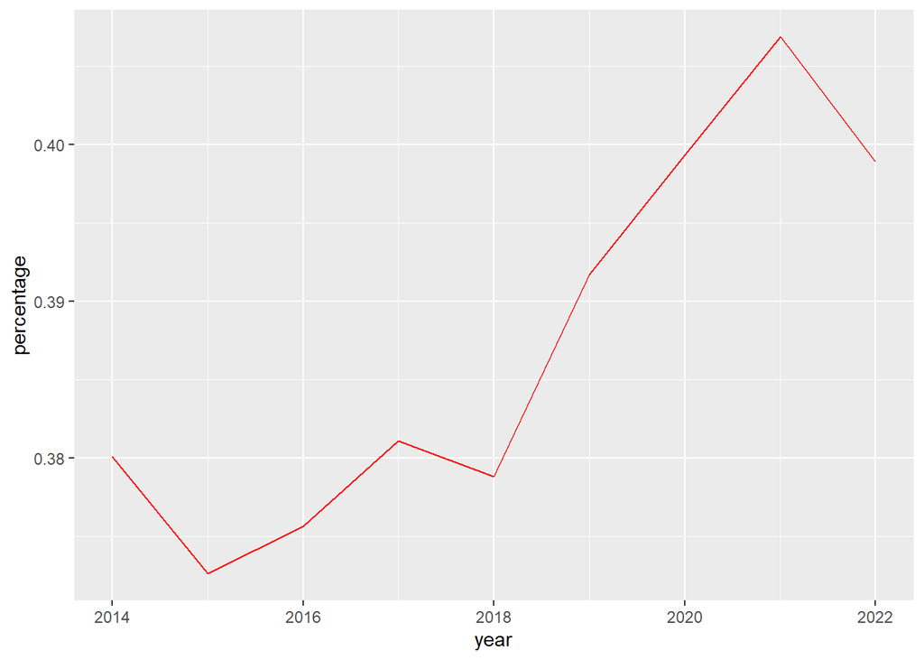

```r
ggplot() + geom_line(data=by_year, aes(x=year, y=percentage), color="red")
```

That’s a pretty sharp increase since 2018. Unfortunately our data only goes back to 2014, but I’d be interested to see what other dips or surges this graph may have in the past 20-30 years as offensive metas change and fads die out. To be fair, it has gone down since last year, but that is also with the caveat that this season isn’t done yet (whatever effect that may have).

To put this in a little more context, I want to see how this compares to all plays on all downs.

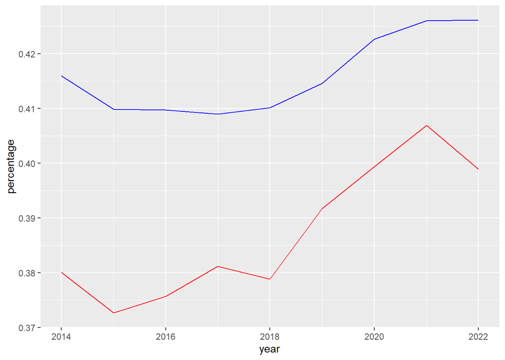

```r
scrimmage <- pbp %>% filter(play_type != 'Punt', !grepl("Kickoff", play_type))
scrimmage_by_year <- scrimmage %>% group_by(year) %>% summarise(passes = sum(pass), count = n()) %>% mutate(percentage = passes/count)
ggplot() + geom_line(data=by_year, aes(x=year, y=percentage), color="red") +
  geom_line(data=scrimmage_by_year, aes(x=year, y=percentage), color="blue")
```

So offensive coordinators have a slightly more conservative than usual approach on first down. That makes sense. We do see though that this rise in frequency on first down also coincides with a similar trend on all downs. It appears that teams are just more likely to throw in general than they have been historically.

Next, we’ll look at all the Big Ten teams. If we use facet wraps, we can plot them all up together.

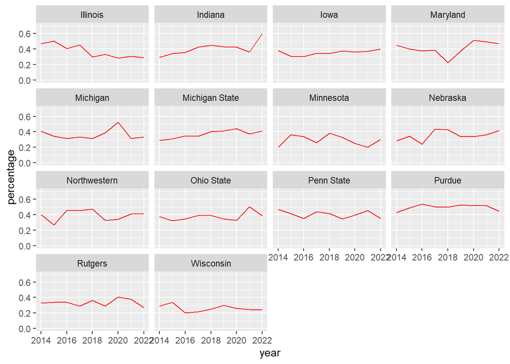

```r
big_ten <- first_downs %>% filter(offense_conference == "Big Ten")
big_ten_by_year <- big_ten %>% group_by(pos_team, year) %>%
  summarise(passes = sum(pass), count = n()) %>%
  mutate(percentage = passes/count)

ggplot() + geom_line(data=big_ten_by_year, aes(x=year, y=percentage), color="red") +
scale_y_continuous(limits = c(0, 0.7)) +
  facet_wrap(~pos_team)
```

So now that we have this, I’m going to add an average line, which shows the average percentage of all teams in the data on first down.

```r
sum(by_year$passes)/sum(by_year$count)
```

```
## [1] 0.3869356
```

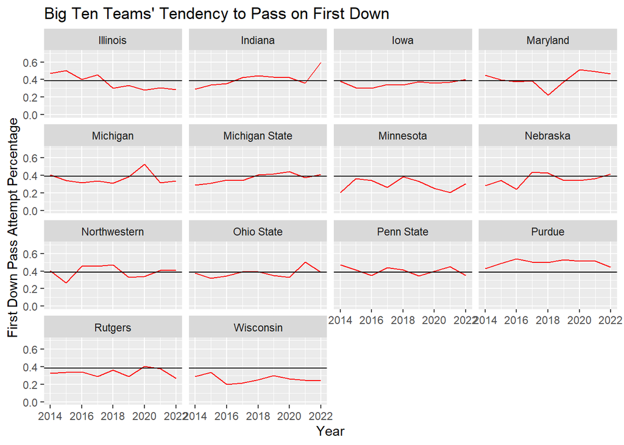

```r
ggplot() + geom_line(data=big_ten_by_year, aes(x=year, y=percentage), color="red") +
    geom_hline(yintercept=0.3869356, color="black") +
    scale_y_continuous(limits = c(0, 0.7)) +
    facet_wrap(~pos_team) + labs(y="First Down Pass Attempt Percentage", x="Year", title="Big Ten Teams' Tendency to Pass on First Down")
```

Lastly, I’m going to see the most pass friendly teams in the data. I’m filtering counts of plays to more than 200. Some of the teams have small sample sizes, which can definitely inflate their numbers.

```r
teams <- first_downs %>% group_by(pos_team, year) %>%
  summarise(passes = sum(pass), count = n()) %>%
  mutate(percentage = passes/count)
teams %>% arrange(desc(percentage)) %>% filter(count > 200)
```

```
## # A tibble: 1,205 × 5
## # Groups:   pos_team [202]
##    pos_team           year passes count percentage
##    <chr>             <dbl>  <dbl> <int>      <dbl>
##  1 Washington State   2019    345   476      0.725
##  2 Washington State   2014    342   493      0.694
##  3 Mississippi State  2020    241   350      0.689
##  4 Mississippi State  2021    337   499      0.675
##  5 Washington State   2017    306   465      0.658
##  6 Washington State   2015    320   491      0.652
##  7 Akron              2014    261   414      0.630
##  8 Virginia           2021    295   475      0.621
##  9 Western Kentucky   2021    339   550      0.616
## 10 Washington State   2018    282   458      0.616
## # … with 1,195 more rows
```

```r
teams %>% arrange(desc(percentage)) %>% filter(count > 200, year == 2022)
```

```
## # A tibble: 199 × 5
## # Groups:   pos_team [199]
##    pos_team           year passes count percentage
##    <chr>             <dbl>  <dbl> <int>      <dbl>
##  1 Mississippi State  2022    193   316      0.611
##  2 Washington State   2022    155   256      0.605
##  3 Indiana            2022    189   315      0.6
##  4 Houston Christian  2022    130   220      0.591
##  5 Akron              2022    165   292      0.565
##  6 Washington         2022    187   341      0.548
##  7 Texas Tech         2022    195   357      0.546
##  8 Georgetown         2022    122   225      0.542
##  9 Georgia Southern   2022    161   298      0.540
## 10 Fordham            2022    139   259      0.537
## # … with 189 more rows
```

Well this is interesting. There is really one man that dominates the top of these lists, and that would be Mike Leach. Leach, who coached at Washington State and now is at Mississippi State, is well-known for his Air Raid offense, which is very pass-aggressive. It shouldn’t be a surprise that his 2022 team is the highest in the country. In fact, when I first had this question, his offensive philosophy came to mind. It’s also funny that his two former schools: Washington State and Texas Tech are both in the top 10.